# Psychoinformatics - Week 4 (Exercises)

## 1 Analyze what videos go viral? (8 points)

Please use [YouTube APIs](https://developers.google.com/youtube/v3/code_samples/python) to carry out a data-driven or hypothesis-driven microstudy about the characteristics of viral videos.

You need to present, here in this notebook, AT LEAST two **statistical** figures or tables as supporting evidence for your arguments. Each of these figures/tables deserves 4 points.

```python
key = 'AIzaSyAUzMOVN4RV3Opf0Z9wIMGLADcXtpVUPpk'
from googleapiclient.discovery import build

def youtube_mostPopular():

    youtube = build('youtube','v3',developerKey=key)
    result = youtube.videos().list(
    part='snippet,statistics',
    chart='mostPopular',
    regionCode='TW',maxResults=50).execute()

    title = []
    viewCount = []
    likeCount = []
    dislikeCount = []
    commentCount = []
    tags = []
    categoryId = []


    for search_result in result.get("items", []):
        if search_result["kind"] == "youtube#video":
            title.append(search_result['snippet']['title'])
            viewCount.append(search_result['statistics']['viewCount'])
            if 'likeCount' in search_result['statistics'].keys():
                likeCount.append(int(search_result['statistics']['likeCount']))
            else:
                likeCount.append(None)
            if 'dislikeCount' in search_result['statistics'].keys():
                dislikeCount.append(int(search_result['statistics']['dislikeCount']))
            else:
                dislikeCount.append(None)
            if 'commentCount' in search_result['statistics'].keys():
                commentCount.append(int(search_result['statistics']['commentCount']))
            else:
                commentCount.append(None)
            if 'tags' in search_result['snippet'].keys():
                tags.append(search_result['snippet']['tags'])
            else:
                tags.append([])
            categoryId.append(search_result['snippet']['categoryId'])



    youtube_dict = {'title':title,'viewCount':viewCount,'likeCount':likeCount,'dislikeCount':dislikeCount,'commentCount':commentCount,'tags': tags,'categoryId':categoryId}

    return youtube_dict
```

```python
# Please carry out your analysis here
import pandas as pd
test = youtube_mostPopular()
df = pd.DataFrame(data=test)
```

# Hypothesis 1:

越熱門的影片曝光率比較高，更容易引來頻道訂閱者以外的觀眾收看，因此更容易接觸到非同溫層的人。 因此我猜想排名越前面的影片可能因此dislike相對於like的比例(dislikeCount/likeCount)會相對較高。 之後採用Kendall's tau來作為相關的指標

```python
df['dislikeRatio'] = df['dislikeCount']/(df['dislikeCount']+df['likeCount'])
df["index"] = np.arange(len(df), 0,-1) # 數字越大為越熱門的影片
df.dropna(inplace = True)
df
```

|  | title | viewCount | likeCount | dislikeCount | commentCount | tags | categoryId | dislikeRatio | index |
| --- | --- | --- | --- | --- | --- | --- | --- | --- | --- |
| 0 | 【盧秀芳辣晚報】3Q團隊喊"出狀況去監票" 狼來了? 刪Q成功 3Q:還有7天立委可做! 恐... | 380245 | 28738 | 263 | 529 | [中天新聞直播, 監督的力量, 主播出任務, Cti Talk, 熱搜發燒榜, 中天電視, ... | 25 | 0.009069 | 50 |
| 1 | 【刪Q特報#LIVE】罷免陳柏惟開票直播特別報導 @中天新聞 20211023 | 372914 | 15277 | 383 | 225 | [中天新聞直播, 中天新聞, 政治, 監督的力量, 主播出任務, Cti Talk, 熱搜發... | 25 | 0.024457 | 49 |
| 2 | 【中天互動LIVE】"罷免陳柏惟" 就看今天 刪Q總部 "開票全記錄" 中天新聞現場直擊... | 412540 | 12942 | 238 | 234 | [中天, 中天電視, 中天新聞, CTI, 會員] | 25 | 0.018058 | 48 |
| 3 | 聽見玻璃心碎的聲音... 黃明志 Ft.陳芳語【玻璃心】@鬼才做音樂 2021 Ghosician | 14928094 | 619643 | 15962 | 131136 | [玻璃心, fragile, 小粉紅, Kimberley Chen, 陳芳語, Kimbe... | 10 | 0.025113 | 47 |
| 4 | 【完整版上集】史上第一次! 成功罷免現任立委 "芒果乾"也救不了陳柏惟? TVBS戰情室 2... | 325441 | 7475 | 447 | 1787 | [少康戰情室, 少康, 習近平, 习近平, XiJinping, 大陸, 中國, 中国, 少... | 25 | 0.056425 | 46 |
| 5 | 【#狗屎寫手】ＱＱㄋㄟㄋㄟ的出處｜#Chill革命 現場版｜ @喬瑟夫 ChillSeph | 517662 | 19672 | 167 | 923 | [STRNetwork, 薩泰爾娛樂, 喜劇, 博恩, 伯恩, 賀瓏, 賀龍, 喬瑟夫, 酸... | 24 | 0.008418 | 45 |
| 6 | 蔡英文救不了陳柏惟 罷免投票率52.63%史上最高! 預言蔡四大公投.罷林昶佐潰敗? 蔡到4... | 516933 | 18959 | 282 | 450 | [新聞大白話, 政論, 新聞, 議題, 評論, 政治, 韓國瑜, 韓流, 謝龍介, 柯文哲,... | 25 | 0.014656 | 44 |
| 7 | 陳柏惟vs.刪Q罷免案開票過程+結果出爐！陳柏惟大戰朱立倫江啟臣顏寬恒！台中二選區沙鹿區、龍... | 253962 | 1578 | 410 | 618 | [94要客訴, 民進黨, 國民黨, 政治, 政論節目, 台灣, 中國, 兩岸, 蔡英文, 美... | 25 | 0.206237 | 43 |
| 8 | 請不要對號入座... 黃明志 Ft.陳芳語【玻璃心】MV 製作花絮 | 839889 | 48862 | 548 | 4294 | [玻璃心, fragile, 小粉紅, Kimberley Chen, 陳芳語, Kimbe... | 24 | 0.011091 | 42 |
| 9 | 被「換臉」成謎片主角只能自認倒霉？Deep Fake 的傷害有多大？｜志祺七七 ft. 魚乾... | 512874 | 25386 | 498 | 3125 | [deepfake, 換臉, 偷臉, faceapp] | 22 | 0.019240 | 41 |
| 10 | 陳柏惟:我沒輸 罷免過7天解職! 四大公投.罷林昶佐 民怨燒蔡英文? 蘇貞昌億來億去到處撒... | 180842 | 9233 | 145 | 382 | [国民大会, 國民大會2020大白話, 于美人, 陳鳳馨, 黃暐瀚, 錢怡君, 习近平, 中... | 25 | 0.015462 | 40 |
| 11 | SEVENTEEN (세븐틴) 'Rock with you' Official MV | 15345634 | 917677 | 3795 | 141574 | [HYBE, HYBE LABELS, 하이브, 하이브레이블즈] | 10 | 0.004118 | 39 |
| 12 | 【正常發揮PiMW】降半旗"今天公祭" 嗨唱歌"3Q忘記“罷前之夜! 網集氣"送陳柏惟回高雄... | 230332 | 27989 | 320 | 1129 | [王又正, 正常發揮, 又正, 少康戰情室, 少康, 習近平, 习近平, XiJinping... | 25 | 0.011304 | 38 |
| 13 | 親哥哥在眼前竟然認不出來！生日慶生被整到不行！♥ 滴妹 | 322796 | 9270 | 122 | 610 | [滴妹, Crown] | 22 | 0.012990 | 37 |
| 14 | 現代高中生的困擾 | 225962 | 10345 | 100 | 488 | [] | 23 | 0.009574 | 36 |
| 15 | TRASH 《離開台北 LEAVING TAIPEI》 Official Music Video | 272677 | 8385 | 56 | 456 | [TRASH, 垃圾, 世界盡頭, 音樂祭, 1111, 宇宙, 能給的只有那麼多, 樂團,... | 10 | 0.006634 | 35 |
| 16 | 【中天互動LIVE】1023陳柏惟罷免投票日 中二選區含大肚.烏日.龍井.霧峰.沙鹿 最大投... | 273983 | 7287 | 153 | 95 | [中天, 中天電視, 中天新聞, CTI, 會員] | 25 | 0.020565 | 34 |
| 17 | 【中天直播#LIVE】向支持鄉親說3Q!下一步?陳柏惟:還沒想過!先一一向支持者說感謝 @中... | 228640 | 6691 | 292 | 68 | [中天, 中天電視, 中天新聞, CTI, 會員] | 25 | 0.041816 | 33 |
| 18 | 陳柏惟罷免案最終結果！開票全解析！ft.黃暐瀚、董智森、陳揮文【#鄉民大會 特別節目】LIVE | 307912 | 11665 | 191 | 708 | [政治, YahooTV, 新聞, 政治人物, Yahoo, 風向台灣, 風向, 鄉民大會,... | 25 | 0.016110 | 32 |
| 19 | #玩很大七週年感謝祭 關於KID涉及在大馬路上跟鬼鬼吵架的重要聲明！開玩笑的啦～我們為了玩粉... | 1352776 | 11037 | 372 | 1733 | [綜藝玩很大, 吳宗憲, KID, 三立都會台, 中視, 中國電視公司, 中視綜藝玩很大, ... | 24 | 0.032606 | 31 |
| 20 | 【FULL】兄弟团齐力寻找财富密码 他们能否带动R村完成“共同富裕”？《奔跑吧·黄河篇第二季... | 404088 | 9852 | 248 | 1292 | [奔跑吧, 奔跑吧黄河篇, 奔跑吧黄河篇第二季, 奔跑吧黄河篇ep1, 奔跑吧黄河2, 奔跑... | 24 | 0.024554 | 30 |
| 21 | 陳柏惟總統級造勢.警犬巡邏! 46死陳其邁不辭職只說不停止檢討! 公祭降半旗 蔡英文只停3分... | 281853 | 15475 | 289 | 236 | [新聞大白話, 政論, 新聞, 議題, 評論, 政治, 韓國瑜, 韓流, 謝龍介, 柯文哲,... | 25 | 0.018333 | 29 |
| 22 | 66歲高向鵬搶救第7天，兒子痛哭再曝病況！昏迷原因終於瞞不住！#高向鵬 #方怡萍 #茶娛飯後 | 365223 | 2299 | 184 | 0 | [] | 1 | 0.074104 | 28 |
| 23 | 【LIVE】刪Q結果出爐！趙少康領軍分析陳柏惟罷免案 如何影響藍綠勢力消長？！ \| 2021... | 176282 | 6888 | 150 | 191 | [新聞大白話, 政論, 新聞, 議題, 評論, 政治, 韓國瑜, 韓流, 謝龍介, 柯文哲,... | 25 | 0.021313 | 27 |
| 24 | 【央視一分鐘】小玉涉「換臉」不雅片遭逮 黃明志.陳芳語MV《玻璃心》狠辱華｜眼球中央電視台 | 613146 | 15476 | 797 | 1755 | [新聞, 中國, 中華民國, 台灣, 政治, 兩岸, 時事, 視網膜, 眼球中央電視台, 央... | 25 | 0.048977 | 26 |
| 25 | 「你總是希望不斷前進，但感受是得停下來的。」- 這集突然變成 #謝盈萱 的諮商實境節目？ | 332621 | 14569 | 95 | 931 | [] | 27 | 0.006478 | 25 |
| 26 | DJ Snake, Ozuna, Megan Thee Stallion, LISA of ... | 27457044 | 2991504 | 48588 | 276544 | [Snake, Ozuna, Megan, Thee, Stallion, LISA, Mu... | 10 | 0.015982 | 24 |
| 27 | 簡舒培逼覆誦蔡英文四個堅持！柯文哲爆氣怒吼「廢話不想唸」 反噹一句話秒讓她語塞｜中時新聞網 | 702981 | 16538 | 810 | 9985 | [中時, cti, 新聞, news, ChinaTimes, 中時電子報, chinati... | 25 | 0.046691 | 23 |
| 28 | 【正常發揮PiMW】綠議員逼"不念四個堅持就道歉"! 柯暴怒嗆:"網軍治國是民主自由?" 陳... | 183909 | 24931 | 201 | 804 | [王又正, 正常發揮, 又正, 少康戰情室, 少康, 習近平, 习近平, XiJinping... | 25 | 0.007998 | 22 |
| 29 | You Don't Belong to Me ("More than Blue" TV Se... | 114356 | 5007 | 27 | 0 | [Eric Chou, Eric 周兴哲, Eric 周興哲, You Don't Belo... | 10 | 0.005364 | 21 |
| 30 | [MV] IU(아이유) _ strawberry moon | 11895015 | 950054 | 8854 | 42446 | [K-POP, Kpop, 1theK, 원더케이, Original, 1theK Ori... | 24 | 0.009233 | 20 |
| 31 | 【完整公開】LIVE 台中市選委會票數統計 陳柏惟罷免案「通過」 | 114362 | 383 | 102 | 56 | [台視新聞, TTV News, TTV LIVE] | 25 | 0.210309 | 19 |
| 32 | 小粉紅怒炸！〈玻璃心〉觀看暴衝600萬 黃明志再酸：留言符合主題｜鏡週刊 | 446937 | 7851 | 252 | 2016 | [鏡週刊, 鏡傳媒, 新聞, 黃明志, 玻璃心, 中國小粉紅, 影射, 陳芳語, 微博, 消... | 25 | 0.031100 | 18 |
| 33 | MULTISUB【这！就是街舞 第四季 Street Dance of China S4】E... | 206155 | 4414 | 91 | 782 | [这！就是街舞 第四季, street dance of china s4, 这就是街舞, ... | 24 | 0.020200 | 17 |
| 34 | 獨家專訪｜陳芳語震碎強國「玻璃心」 親回挨轟難相處、搶賺人民幣黑歷史 \| 台灣新聞 Taiw... | 421991 | 9668 | 223 | 1981 | [新聞, 蘋果新聞網, 即時新聞, Taiwan, 蘋果, 娛樂新聞, 台灣, 台灣新聞, ... | 25 | 0.022546 | 16 |
| 35 | 你們家裡也有情緒勒索的米蟲嗎？ \| Onion Man | 144236 | 4562 | 999 | 736 | [onionman, 洋蔥, 阿文, 啾啾鞋, 放火, 小玉, 聖結石, 上班不要看, ho... | 1 | 0.179644 | 15 |
| 36 | [최종회] '날 비춘 건 바로 너야' ♬Shine @COMPLETION MISSIO... | 1934838 | 125649 | 1039 | 6533 | [BackKooYoung, JangJuHee, JoAYoung, LimHanByul... | 24 | 0.008201 | 14 |
| 37 | 【央視一分鐘】網再掀黃明志陳芳語辱華歷史 NBA球星解放西藏 陸禁播賽爾提克賽事｜眼球中央電視台 | 386670 | 9510 | 346 | 1775 | [新聞, 中國, 中華民國, 台灣, 政治, 兩岸, 時事, 視網膜, 眼球中央電視台, 央... | 25 | 0.035106 | 13 |
| 38 | Brawl Stars: Brawl Talk - Lights, Camera, BRAWL! | 6036536 | 507348 | 5011 | 34760 | [brawl stars, mobile game, mobile strategy gam... | 20 | 0.009780 | 12 |
| 39 | 廢物莎莎挑戰「一週自律魔人」生活💪🏻身體竟然產生超神奇的變化…..｜愛莉莎莎Alisasa | 372371 | 13542 | 300 | 923 | [] | 22 | 0.021673 | 11 |
| 40 | 【MV首播】楊哲 vs 謝宜君 - 你哪會不識我 (官方完整版MV) HD 【三立八點檔『天... | 81235 | 1608 | 51 | 84 | [豪記, 上豪, 豪聲, MV首播, 台語歌, 台語新歌, 台灣流行樂, 福建, 閩南語, ... | 10 | 0.030741 | 10 |
| 41 | "台灣熱炒"飄香曼哈頓！思鄉遊子將"板凳.酒杯"帶入紐約 熱炒店充滿"台味"...開店一年登... | 808015 | 12027 | 344 | 1080 | [三立新聞, 國際, 大世界, 中國, 美國, 貿易, 歐美, 全球, 奇聞, 韓國, 趣聞... | 25 | 0.027807 | 9 |
| 42 | 【豆漿&俊榮】 洗貓真的好煩阿阿阿阿 | 446022 | 17377 | 93 | 1018 | [豆漿貓, 娘娘, 宅男, 寵物, 俊榮, 阿晧, 工程師, 療癒, 可愛, 萌寵, 豆漿,... | 15 | 0.005323 | 8 |
| 43 | 跟唄姬穿搭風格互換！不可以色色！三蘆混血兒間的對決！Feat.@臺灣尋奇 唄姬【我是蕾菈I... | 202912 | 3901 | 67 | 199 | [反骨, 蕾菈, 酷炫, 孫生] | 22 | 0.016885 | 7 |
| 44 | 同意票超過罷免門檻 陳柏惟確定遭罷免！同意77899票vs.不同意73433票 關鍵一役結果... | 210657 | 1005 | 806 | 279 | [三立新聞, 最新消息, LIVE, 三立iNEWS, 三立, 新聞, 直播, 網路直播, ... | 25 | 0.445058 | 6 |
| 45 | 盧廣仲 Crowd Lu【自我的介紹 in peace】Official Music Video | 138832 | 4802 | 32 | 458 | [盧廣仲, Crowd Lu, 自我的介紹, in peace, MV, Teaser, 卢... | 10 | 0.006620 | 5 |
| 46 | #抖音神曲2021 %抖音流行歌曲 2021 TIK TOK抖音音樂熱門歌單 \ 2021四... | 29472 | 178 | 15 | 3 | [抖音神曲2021, 抖音, 十一月, 抖音合集, 十一月热门歌曲, 洗脑抖音歌曲, TIK... | 10 | 0.077720 | 4 |
| 47 | 66歲高向鵬昏迷6天未醒，家人已做最壞打算，方怡萍嚇到生活停擺【娛樂星鮮事】#高向鵬#大牌哥... | 159047 | 1021 | 82 | 0 | [] | 24 | 0.074343 | 3 |
| 48 | 我的世界：当装备可以添加各种超级附魔，如果通关MC？ | 49896 | 1056 | 28 | 37 | [《我的世界》, Speedrunner vs 3猎人, 《我的世界》挑战, 挑战, 击败《... | 20 | 0.025830 | 2 |
| 49 | 這群人 TGOP │那些爸媽曾經對你說過的謊 Lies Your Parents Told You | 1137727 | 26836 | 480 | 1534 | [這群人, TGOP, 搞笑影片, This, Group, Of, People, 茵聲,... | 24 | 0.017572 | 1 |

```
-0.11836734693877553
0.22516638224112473
AxesSubplot(0.125,0.125;0.775x0.755)
```

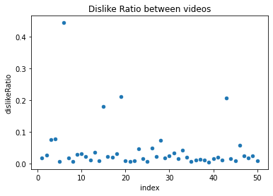

```python
import scipy.stats as stats
tau, p_value = stats.kendalltau(df['index'],df['dislikeRatio'])
print(tau)
print(p_value)
print(df.plot.scatter('index','dislikeRatio',title = "Dislike Ratio between videos"))
```

## Kendall's tau 約為 -0.11, p-value約0.225

由統計結果以及散布圖可知倒讚的比例跟發燒影片沒什麼相關，但也有可能是因為只獲得發燒影片的資料，沒有分析非發燒影片的資料，樣本性質太相近因此無法確定倒讚比例跟熱門程度的關連。

# 2. 大多數是什麼類型的影片？

我認為應該主要應該是娛樂性質的影片偏多

```python
categoryDict = {
'2':'Autos & Vehicles',
'1' :'Film & Animation',
'10':'Music',
'15':'Pets & Animals',
'17':'Sports',
'18':'Short Movies',
'19':'Travel & Events',
'20':'Gaming',
'21':'Videoblogging',
'22':'People & Blogs',
'23':'Comedy',
'24':'Entertainment',
'25':'News & Politics',
'26':'Howto & Style',
'27':'Education',
'28':'Science & Technology',
'29':'Nonprofits & Activism',
'30':'Movies',
'31':'Anime/Animation',
'32':'Action/Adventure',
'33':'Classics',
'34':'Comedy',
'35':'Documentary',
'36':'Drama',
'37':'Family',
'38':'Foreign',
'39':'Horror',
'40':'Sci-Fi/Fantasy',
'41':'Thriller',
'42':'Shorts',
'43':'Shows',
'44':'Trailers'
}

df['categoryId'] = df['categoryId'].apply(lambda x: categoryDict[x])
```

```python
df2 = pd.DataFrame()
df2['categoryCounts'] = pd.DataFrame(df['categoryId'].value_counts())
display(df2)
display(df[['title','categoryId']])
```

|  | categoryCounts |
| --- | --- |
| News & Politics | 22 |
| Entertainment | 9 |
| Music | 8 |
| People & Blogs | 4 |
| Film & Animation | 2 |
| Gaming | 2 |
| Comedy | 1 |
| Education | 1 |
| Pets & Animals | 1 |

|  | title | categoryId |
| --- | --- | --- |
| 0 | 【盧秀芳辣晚報】3Q團隊喊"出狀況去監票" 狼來了? 刪Q成功 3Q:還有7天立委可做! 恐... | News & Politics |
| 1 | 【刪Q特報#LIVE】罷免陳柏惟開票直播特別報導 @中天新聞 20211023 | News & Politics |
| 2 | 【中天互動LIVE】"罷免陳柏惟" 就看今天 刪Q總部 "開票全記錄" 中天新聞現場直擊... | News & Politics |
| 3 | 聽見玻璃心碎的聲音... 黃明志 Ft.陳芳語【玻璃心】@鬼才做音樂 2021 Ghosician | Music |
| 4 | 【完整版上集】史上第一次! 成功罷免現任立委 "芒果乾"也救不了陳柏惟? TVBS戰情室 2... | News & Politics |
| 5 | 【#狗屎寫手】ＱＱㄋㄟㄋㄟ的出處｜#Chill革命 現場版｜ @喬瑟夫 ChillSeph | Entertainment |
| 6 | 蔡英文救不了陳柏惟 罷免投票率52.63%史上最高! 預言蔡四大公投.罷林昶佐潰敗? 蔡到4... | News & Politics |
| 7 | 陳柏惟vs.刪Q罷免案開票過程+結果出爐！陳柏惟大戰朱立倫江啟臣顏寬恒！台中二選區沙鹿區、龍... | News & Politics |
| 8 | 請不要對號入座... 黃明志 Ft.陳芳語【玻璃心】MV 製作花絮 | Entertainment |
| 9 | 被「換臉」成謎片主角只能自認倒霉？Deep Fake 的傷害有多大？｜志祺七七 ft. 魚乾... | People & Blogs |
| 10 | 陳柏惟:我沒輸 罷免過7天解職! 四大公投.罷林昶佐 民怨燒蔡英文? 蘇貞昌億來億去到處撒... | News & Politics |
| 11 | SEVENTEEN (세븐틴) 'Rock with you' Official MV | Music |
| 12 | 【正常發揮PiMW】降半旗"今天公祭" 嗨唱歌"3Q忘記“罷前之夜! 網集氣"送陳柏惟回高雄... | News & Politics |
| 13 | 親哥哥在眼前竟然認不出來！生日慶生被整到不行！♥ 滴妹 | People & Blogs |
| 14 | 現代高中生的困擾 | Comedy |
| 15 | TRASH 《離開台北 LEAVING TAIPEI》 Official Music Video | Music |
| 16 | 【中天互動LIVE】1023陳柏惟罷免投票日 中二選區含大肚.烏日.龍井.霧峰.沙鹿 最大投... | News & Politics |
| 17 | 【中天直播#LIVE】向支持鄉親說3Q!下一步?陳柏惟:還沒想過!先一一向支持者說感謝 @中... | News & Politics |
| 18 | 陳柏惟罷免案最終結果！開票全解析！ft.黃暐瀚、董智森、陳揮文【#鄉民大會 特別節目】LIVE | News & Politics |
| 19 | #玩很大七週年感謝祭 關於KID涉及在大馬路上跟鬼鬼吵架的重要聲明！開玩笑的啦～我們為了玩粉... | Entertainment |
| 20 | 【FULL】兄弟团齐力寻找财富密码 他们能否带动R村完成“共同富裕”？《奔跑吧·黄河篇第二季... | Entertainment |
| 21 | 陳柏惟總統級造勢.警犬巡邏! 46死陳其邁不辭職只說不停止檢討! 公祭降半旗 蔡英文只停3分... | News & Politics |
| 22 | 66歲高向鵬搶救第7天，兒子痛哭再曝病況！昏迷原因終於瞞不住！#高向鵬 #方怡萍 #茶娛飯後 | Film & Animation |
| 23 | 【LIVE】刪Q結果出爐！趙少康領軍分析陳柏惟罷免案 如何影響藍綠勢力消長？！ \| 2021... | News & Politics |
| 24 | 【央視一分鐘】小玉涉「換臉」不雅片遭逮 黃明志.陳芳語MV《玻璃心》狠辱華｜眼球中央電視台 | News & Politics |
| 25 | 「你總是希望不斷前進，但感受是得停下來的。」- 這集突然變成 #謝盈萱 的諮商實境節目？ | Education |
| 26 | DJ Snake, Ozuna, Megan Thee Stallion, LISA of ... | Music |
| 27 | 簡舒培逼覆誦蔡英文四個堅持！柯文哲爆氣怒吼「廢話不想唸」 反噹一句話秒讓她語塞｜中時新聞網 | News & Politics |
| 28 | 【正常發揮PiMW】綠議員逼"不念四個堅持就道歉"! 柯暴怒嗆:"網軍治國是民主自由?" 陳... | News & Politics |
| 29 | You Don't Belong to Me ("More than Blue" TV Se... | Music |
| 30 | [MV] IU(아이유) _ strawberry moon | Entertainment |
| 31 | 【完整公開】LIVE 台中市選委會票數統計 陳柏惟罷免案「通過」 | News & Politics |
| 32 | 小粉紅怒炸！〈玻璃心〉觀看暴衝600萬 黃明志再酸：留言符合主題｜鏡週刊 | News & Politics |
| 33 | MULTISUB【这！就是街舞 第四季 Street Dance of China S4】E... | Entertainment |
| 34 | 獨家專訪｜陳芳語震碎強國「玻璃心」 親回挨轟難相處、搶賺人民幣黑歷史 \| 台灣新聞 Taiw... | News & Politics |
| 35 | 你們家裡也有情緒勒索的米蟲嗎？ \| Onion Man | Film & Animation |
| 36 | [최종회] '날 비춘 건 바로 너야' ♬Shine @COMPLETION MISSIO... | Entertainment |
| 37 | 【央視一分鐘】網再掀黃明志陳芳語辱華歷史 NBA球星解放西藏 陸禁播賽爾提克賽事｜眼球中央電視台 | News & Politics |
| 38 | Brawl Stars: Brawl Talk - Lights, Camera, BRAWL! | Gaming |
| 39 | 廢物莎莎挑戰「一週自律魔人」生活💪🏻身體竟然產生超神奇的變化…..｜愛莉莎莎Alisasa | People & Blogs |
| 40 | 【MV首播】楊哲 vs 謝宜君 - 你哪會不識我 (官方完整版MV) HD 【三立八點檔『天... | Music |
| 41 | "台灣熱炒"飄香曼哈頓！思鄉遊子將"板凳.酒杯"帶入紐約 熱炒店充滿"台味"...開店一年登... | News & Politics |
| 42 | 【豆漿&俊榮】 洗貓真的好煩阿阿阿阿 | Pets & Animals |
| 43 | 跟唄姬穿搭風格互換！不可以色色！三蘆混血兒間的對決！Feat.@臺灣尋奇 唄姬【我是蕾菈I... | People & Blogs |
| 44 | 同意票超過罷免門檻 陳柏惟確定遭罷免！同意77899票vs.不同意73433票 關鍵一役結果... | News & Politics |
| 45 | 盧廣仲 Crowd Lu【自我的介紹 in peace】Official Music Video | Music |
| 46 | #抖音神曲2021 %抖音流行歌曲 2021 TIK TOK抖音音樂熱門歌單 \ 2021四... | Music |
| 47 | 66歲高向鵬昏迷6天未醒，家人已做最壞打算，方怡萍嚇到生活停擺【娛樂星鮮事】#高向鵬#大牌哥... | Entertainment |
| 48 | 我的世界：当装备可以添加各种超级附魔，如果通关MC？ | Gaming |
| 49 | 這群人 TGOP │那些爸媽曾經對你說過的謊 Lies Your Parents Told You | Entertainment |

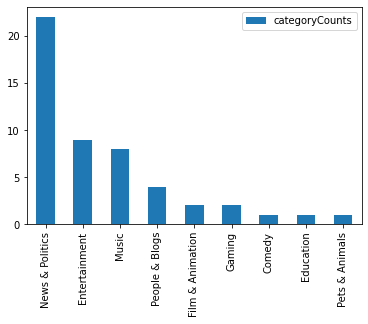

```python
df2.plot.bar()
```

# Results

### Please submit this file to NTU COOL before next Monday (10/25).